# Storm Data Analysis

Arif Attar

April 8, 2018

# The Most Damaging Storm and Weather Event Types in the United States of America between 1950 and 2011

## Synopsis

This report explores the U.S. National Oceanic and Atmospheric Administration’s (NOAA) storm database. This database tracks characteristics of major storms and weather events in the United States, including when and where they occur, as well as estimates of any fatalities, injuries, and property damage.The aim was primarily to determine which storm and weather event types were the most harmful in terms of health of the population and had the greatest economic consequences. The analysis of the data reveals that tornadoes the most harmful in terms of health of the population. Floods have the greatest economic consequences in terms of damage to property and droughts have the greatest economic consequences in terms of damage to crops.

## Data Processing

The data for this report was downloaded from https://d396qusza40orc.cloudfront.net/repdata%2Fdata%2FStormData.csv.bz2.

### Reading in the data

As this file is compressed via the bz2 algorithm, it was unzipped and stored as a CSV file.

```r
StormData <- read.csv("repdata%2Fdata%2FStormData.csv")
```

### Exploration of the dataset

After reading the data, an initial exploration of the dataset was done.

The dataset has 902297 rows and 37 columns

```r
dim(StormData)
```

```
## [1] 902297     37
```

The names of the variables stored in the columns are as follows:

```r
names(StormData)
```

```
##  [1] "STATE__"    "BGN_DATE"   "BGN_TIME"   "TIME_ZONE"  "COUNTY"
##  [6] "COUNTYNAME" "STATE"      "EVTYPE"     "BGN_RANGE"  "BGN_AZI"
## [11] "BGN_LOCATI" "END_DATE"   "END_TIME"   "COUNTY_END" "COUNTYENDN"
## [16] "END_RANGE"  "END_AZI"    "END_LOCATI" "LENGTH"     "WIDTH"
## [21] "F"          "MAG"        "FATALITIES" "INJURIES"   "PROPDMG"
## [26] "PROPDMGEXP" "CROPDMG"    "CROPDMGEXP" "WFO"        "STATEOFFIC"
## [31] "ZONENAMES"  "LATITUDE"   "LONGITUDE"  "LATITUDE_E" "LONGITUDE_"
## [36] "REMARKS"    "REFNUM"
```

The top of the dataset with select columns looks like this:

```r
head(StormData[,c(1,2,3,4,5,6,7,8,23,24,25,26,27,28)])
```

```
##   STATE__           BGN_DATE BGN_TIME TIME_ZONE COUNTY COUNTYNAME STATE
## 1       1  4/18/1950 0:00:00     0130       CST     97     MOBILE    AL
## 2       1  4/18/1950 0:00:00     0145       CST      3    BALDWIN    AL
## 3       1  2/20/1951 0:00:00     1600       CST     57    FAYETTE    AL
## 4       1   6/8/1951 0:00:00     0900       CST     89    MADISON    AL
## 5       1 11/15/1951 0:00:00     1500       CST     43    CULLMAN    AL
## 6       1 11/15/1951 0:00:00     2000       CST     77 LAUDERDALE    AL
##    EVTYPE FATALITIES INJURIES PROPDMG PROPDMGEXP CROPDMG CROPDMGEXP
## 1 TORNADO          0       15    25.0          K       0
## 2 TORNADO          0        0     2.5          K       0
## 3 TORNADO          0        2    25.0          K       0
## 4 TORNADO          0        2     2.5          K       0
## 5 TORNADO          0        2     2.5          K       0
## 6 TORNADO          0        6     2.5          K       0
```

and the bottom of the dataset with select columns looks like this:

```r
tail(StormData[,c(1,2,3,4,5,6,7,8,23,24,25,26,27,28)])
```

```
##        STATE__           BGN_DATE    BGN_TIME TIME_ZONE COUNTY
## 902292      47 11/28/2011 0:00:00 03:00:00 PM       CST     21
## 902293      56 11/30/2011 0:00:00 10:30:00 PM       MST      7
## 902294      30 11/10/2011 0:00:00 02:48:00 PM       MST      9
## 902295       2  11/8/2011 0:00:00 02:58:00 PM       AKS    213
## 902296       2  11/9/2011 0:00:00 10:21:00 AM       AKS    202
## 902297       1 11/28/2011 0:00:00 08:00:00 PM       CST      6
##                                  COUNTYNAME STATE         EVTYPE
## 902292 TNZ001>004 - 019>021 - 048>055 - 088    TN WINTER WEATHER
## 902293                         WYZ007 - 017    WY      HIGH WIND
## 902294                         MTZ009 - 010    MT      HIGH WIND
## 902295                               AKZ213    AK      HIGH WIND
## 902296                               AKZ202    AK       BLIZZARD
## 902297                               ALZ006    AL     HEAVY SNOW
##        FATALITIES INJURIES PROPDMG PROPDMGEXP CROPDMG CROPDMGEXP
## 902292          0        0       0          K       0          K
## 902293          0        0       0          K       0          K
## 902294          0        0       0          K       0          K
## 902295          0        0       0          K       0          K
## 902296          0        0       0          K       0          K
## 902297          0        0       0          K       0          K
```

For the purpose of our current analysis the most important variable is “EVTYPE” which shows the type of weather event associated with the particular observation. This variable is explored next.

```r
str(StormData$EVTYPE)
```

```
##  Factor w/ 985 levels "   HIGH SURF ADVISORY",..: 834 834 834 834 834 834 834 834 834 834 ...
```

“EVTYPE” is a FACTOR variable containing 985 different weather event types.

The 20-most frequently occurring weather event types in the United States of America between 1950 and 2011 are:

```r
TopEVTYPE <- head(summary(StormData$EVTYPE),20)
TopEVTYPE
```

```
##                     HAIL                TSTM WIND        THUNDERSTORM WIND
##                   288661                   219940                    82563
##                  TORNADO              FLASH FLOOD                    FLOOD
##                    60652                    54277                    25326
##       THUNDERSTORM WINDS                HIGH WIND                LIGHTNING
##                    20843                    20212                    15754
##               HEAVY SNOW               HEAVY RAIN             WINTER STORM
##                    15708                    11723                    11433
##           WINTER WEATHER             FUNNEL CLOUD         MARINE TSTM WIND
##                     7026                     6839                     6175
## MARINE THUNDERSTORM WIND               WATERSPOUT              STRONG WIND
##                     5812                     3796                     3566
##     URBAN/SML STREAM FLD                 WILDFIRE
##                     3392                     2761
```

As can be seen above, some of the event types which are the same have been classified into different event types because of different terminologies used. For example, TSTM Wind, Thunderstorm Wind and Thunderstorm Winds represent the same event type, namely, Thunderstorm Wind and as such should be collapsed into a single event type. So the next step was to collapse these different event types into a single event type.

This was done for event types Thunderstorm Wind and Marine Thunderstorm Wind, and also Hurricane and Flash Flood. From the Storm Data documentation https://d396qusza40orc.cloudfront.net/repdata%2Fpeer2_doc%2Fpd01016005curr.pdf, it is stated on page 32 that River Flood should be classified as Flash Flood.

```r
levels(StormData$EVTYPE)[levels(StormData$EVTYPE)=="TSTM WIND"| levels(StormData$EVTYPE)== "THUNDERSTORM WINDS"] <- "THUNDERSTORM WIND"
levels(StormData$EVTYPE)[levels(StormData$EVTYPE)=="MARINE TSTM WIND"] <- "MARINE THUNDERSTORM WIND"
levels(StormData$EVTYPE)[levels(StormData$EVTYPE)=="HURRICANE/TYPHOON"] <- "HURRICANE"
levels(StormData$EVTYPE)[levels(StormData$EVTYPE)=="RIVER FLOOD"] <- "FLASH FLOOD"
str(StormData$EVTYPE)
```

```
##  Factor w/ 980 levels "   HIGH SURF ADVISORY",..: 830 830 830 830 830 830 830 830 830 830 ...
```

After this transformation, the number of levels of EVTYPE variabe has now collapsed to 980.

This changes the 20-most frequently occurring weather event types in the United States of America between 1950 and 2011 as follows:

```r
TopEVTYPE <- head(summary(StormData$EVTYPE),20)
TopEVTYPE
```

```
##        THUNDERSTORM WIND                     HAIL                  TORNADO
##                   323346                   288661                    60652
##              FLASH FLOOD                    FLOOD                HIGH WIND
##                    54450                    25326                    20212
##                LIGHTNING               HEAVY SNOW MARINE THUNDERSTORM WIND
##                    15754                    15708                    11987
##               HEAVY RAIN             WINTER STORM           WINTER WEATHER
##                    11723                    11433                     7026
##             FUNNEL CLOUD               WATERSPOUT              STRONG WIND
##                     6839                     3796                     3566
##     URBAN/SML STREAM FLD                 WILDFIRE                 BLIZZARD
##                     3392                     2761                     2719
##                  DROUGHT                ICE STORM
##                     2488                     2006
```

Thunderstorm Wind is the most frequently occuring weather event type in the USA according to the dataset followed by Hail and then Tornado.

A barplot reveals that Thunderstorm Wind and Hail make up a substantial proportion of all the weather event types.

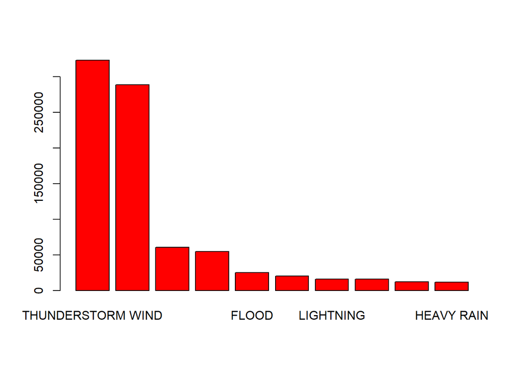

```r
barplot(head(TopEVTYPE,10), col = "RED")
```

## Results

This analysis is focused on answering two questions: 1. Which weather event types are most harmful to population health? 2. Which weather event types have the greatest economic consequences?

### 1. Which weather event types are most harmful to population health?

To answer this question, the variables of interest are EVTYPE, FATALITIES and INJURIES. FATALITIES report the number of fatalities that occured as a result of that particular weather event and INJURIES report the number of injuries that occured as a result of that particular weather event.

A new data set is created which sums the number of FATALITIES grouped by EVTYPE and number of INJURIES grouped by EVTYPE

```r
library(dplyr)
HealthStormData <- StormData %>% group_by(EVTYPE) %>% summarise_at(vars(FATALITIES, INJURIES), sum)
str(HealthStormData)
```

```
## Classes 'tbl_df', 'tbl' and 'data.frame':    980 obs. of  3 variables:
##  $ EVTYPE    : Factor w/ 980 levels "   HIGH SURF ADVISORY",..: 1 2 3 4 5 6 7 8 9 10 ...
##  $ FATALITIES: num  0 0 0 0 0 0 0 0 0 0 ...
##  $ INJURIES  : num  0 0 0 0 0 0 0 0 0 0 ...
```

The new data set has three columns with FATALITIES containing the sum of all fatalities associated with the corresponding EVTYPE and INJURIES containing the sum of all injuries associated with the corresponding EVTYPE.

The dataset sorted by descending numbers of fatalities

```r
HealthStormDatabyF <- HealthStormData[order(-HealthStormData$FATALITIES),]
a <- head(HealthStormDatabyF[,c(1,2)], 10)
a
```

```
## # A tibble: 10 x 2
##    EVTYPE            FATALITIES
##    <fct>                  <dbl>
##  1 TORNADO                5633.
##  2 EXCESSIVE HEAT         1903.
##  3 FLASH FLOOD             980.
##  4 HEAT                    937.
##  5 LIGHTNING               816.
##  6 THUNDERSTORM WIND       701.
##  7 FLOOD                   470.
##  8 RIP CURRENT             368.
##  9 HIGH WIND               248.
## 10 AVALANCHE               224.
```

It can be concluded from the above list that in terms of number of fatalities, TORNADO is the weather event type most harmful to population health, followed by events classified as EXCESSIVE HEAT, FLASH FLOOD, HEAT, LIGHTNING etc.

The dataset sorted by descending numbers of injuries

```r
HealthStormDatabyI <- HealthStormData[order(-HealthStormData$INJURIES),]
b <- head(HealthStormDatabyI[,c(1,3)], 10)
b
```

```
## # A tibble: 10 x 2
##    EVTYPE            INJURIES
##    <fct>                <dbl>
##  1 TORNADO             91346.
##  2 THUNDERSTORM WIND    9353.
##  3 FLOOD                6789.
##  4 EXCESSIVE HEAT       6525.
##  5 LIGHTNING            5230.
##  6 HEAT                 2100.
##  7 ICE STORM            1975.
##  8 FLASH FLOOD          1779.
##  9 HAIL                 1361.
## 10 HURRICANE            1321.
```

It can be concluded from the above list that in terms of number of injuries, TORNADO is the weather event type most harmful to population health, followed by events classified as THUNDERSTORM WIND, FLOOD, EXCESSIVE HEAT, LIGHTNING etc.

Plotting the results as a barplot

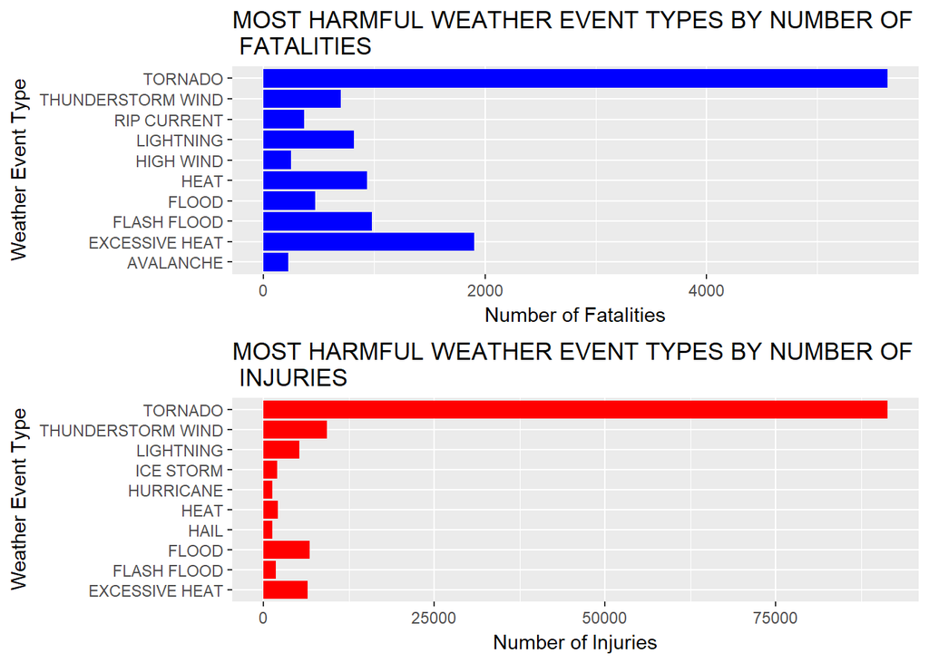

```r
library(ggplot2)
library(gridExtra)
plot1 <- ggplot(data = head(a,10)) + geom_col(aes(x= EVTYPE, y = FATALITIES), fill = "blue") + ggtitle("MOST HARMFUL WEATHER EVENT TYPES BY NUMBER OF\n FATALITIES") + xlab("Weather Event Type") + ylab("Number of Fatalities") + coord_flip()
plot2 <- ggplot(data = head(b,10)) + geom_col(aes(x = EVTYPE, y = INJURIES), fill = "red") + ggtitle("MOST HARMFUL WEATHER EVENT TYPES BY NUMBER OF \n INJURIES") + xlab("Weather Event Type") + ylab("Number of Injuries") + coord_flip()
grid.arrange(plot1, plot2, nrow = 2)
```

### 2. Which weather event types have the greatest economic consequences?

To answer this question the variables of interest are “EVTYPE”,“PROPDMG”, “PROPDMGEXP”, “CROPDMG” and “CROPDMGEXP”

Economic consequences can be in terms of damage to property (“”PROPDMG“,”PROPDMGEXP“”) and damage to crops (“CROPDMG” and “CROPDMGEXP”)

The analysis first tackles damage to property

PROPDMG contains the dollar value of the damage to property from particular weather event and PROPDMGEXP contains the letters denoting whether the figures in PROPDMG are in Thousands(K) or Millions(M) or Billions(B)

First, a subset of the StormData dataset is created to include only those observations where the value for PROPDMG > 0. The weather events which did not have any property damage cost are not useful for this part of the analysis.

```r
PropStormData <- subset(StormData, PROPDMG != 0)
nrow(PropStormData)
```

```
## [1] 239174
```

The PropStormData dataset has 239174 observations

```r
str(PropStormData$PROPDMGEXP)
```

```
##  Factor w/ 19 levels "","-","?","+",..: 17 17 17 17 17 17 17 17 17 17 ...
```

```r
summary(PropStormData$PROPDMGEXP)
```

```
##             -      ?      +      0      1      2      3      4      5
##     76      1      0      5    209      0      1      1      4     18
##      6      7      8      B      h      H      K      m      M
##      3      2      0     40      1      6 227481      7  11319
```

From the above it can be observed that PROPDMGEXP is a factor variable and it has other levels apart from K, M and B. This analysis ignores the other levels and only considers, H, h, K, M, m and B

For the purpose of this analysis the figures in PROPDMG have to be modified such that they include the whole figure for the property damage. Hence the figure in PROPDMG has to be multiplied by 1000 if the corresponding letter in PROPDMGEXP is K, multiplied by 1000000 if it is M and 1000000000 if it is B.

```r
for (i in 1:nrow(PropStormData)) {
    if (PropStormData$PROPDMGEXP[i] == "K") {
             PropStormData$PROPDMG[i] = PropStormData$PROPDMG[i] * 1000
             } else
             if ((PropStormData$PROPDMGEXP[i] == "M")| (PropStormData$PROPDMGEXP[i] == "m")) {
                 PropStormData$PROPDMG[i] = PropStormData$PROPDMG[i] * 1000000
                 } else
                   if (PropStormData$PROPDMGEXP[i] == "B") {
                      PropStormData$PROPDMG[i] = PropStormData$PROPDMG[i] * 1000000000
                      } else
                        if ((PropStormData$PROPDMGEXP[i] == "H")| (PropStormData$PROPDMGEXP[i] == "h")) {
                                   PropStormData$PROPDMG[i] = PropStormData$PROPDMG[i] * 100
                                   } else
                                          {
                                           PropStormData$PROPDMG[i] = PropStormData$PROPDMG[i] * 1
                                         }

}
```

Viewing the top rows of PropStormData with selected columns

```r
head(PropStormData[,c(1,2,3,4,5,6,7,8,23,24,25,26,27,28)])
```

```
##   STATE__           BGN_DATE BGN_TIME TIME_ZONE COUNTY COUNTYNAME STATE
## 1       1  4/18/1950 0:00:00     0130       CST     97     MOBILE    AL
## 2       1  4/18/1950 0:00:00     0145       CST      3    BALDWIN    AL
## 3       1  2/20/1951 0:00:00     1600       CST     57    FAYETTE    AL
## 4       1   6/8/1951 0:00:00     0900       CST     89    MADISON    AL
## 5       1 11/15/1951 0:00:00     1500       CST     43    CULLMAN    AL
## 6       1 11/15/1951 0:00:00     2000       CST     77 LAUDERDALE    AL
##    EVTYPE FATALITIES INJURIES PROPDMG PROPDMGEXP CROPDMG CROPDMGEXP
## 1 TORNADO          0       15   25000          K       0
## 2 TORNADO          0        0    2500          K       0
## 3 TORNADO          0        2   25000          K       0
## 4 TORNADO          0        2    2500          K       0
## 5 TORNADO          0        2    2500          K       0
## 6 TORNADO          0        6    2500          K       0
```

Comparing the PROPDMG variable in the PropStormData dataset with the PROPDMG variable in the StormData dataset, it can be seen that the values are now incorporating the Ks and Ms in the PROPDMGEXP variable.

A new dataset is created which sums the damage to property in dollar terms (PROPDMG) grouped by weather event type (EVTYPE)

```r
library(dplyr)
PropStormDatabyEType <- PropStormData %>% group_by(EVTYPE) %>% summarise_at(vars(PROPDMG), sum)
str(PropStormDatabyEType)
```

```
## Classes 'tbl_df', 'tbl' and 'data.frame':    401 obs. of  2 variables:
##  $ EVTYPE : Factor w/ 980 levels "   HIGH SURF ADVISORY",..: 1 3 5 6 9 15 16 17 19 21 ...
##  $ PROPDMG: num  200000 50000 8100000 8000 5000 ...
```

The dataset sorted by descending sum of damage to property

```r
PropStormDatabyEType <- PropStormDatabyEType[order(-PropStormDatabyEType$PROPDMG),]
c <- head(PropStormDatabyEType, 10)
c
```

```
## # A tibble: 10 x 2
##    EVTYPE                  PROPDMG
##    <fct>                     <dbl>
##  1 FLOOD             144657709807.
##  2 HURRICANE          81174159010.
##  3 TORNADO            56937160779.
##  4 STORM SURGE        43323536000.
##  5 FLASH FLOOD        21259757567.
##  6 HAIL               15732267543.
##  7 THUNDERSTORM WIND   9704010782.
##  8 TROPICAL STORM      7703890550.
##  9 WINTER STORM        6688497251.
## 10 HIGH WIND           5270046295.
```

It can be concluded from the above list that in terms of damage to property weather event type “FLOOD” has the greatest economic consequences, followed by “HURRICANE”, “TORNADO”, “STORM SURGE”, “FLASH FLOOD”, etc.

The analysis now tackles damage to crops.

A similar process as above is now done with the variables CROPDMG and CROPDMGEXP

CROPDMG contains the dollar value of the damage to crops from particular weather event and CROPDMGEXP contains the letters denoting whether the figures in CROPDMG are in Thousands(K) or Millions(M) or Billions(B)

First, a subset of the StormData dataset is created to include only those observations where the value for CROPDMG > 0. The weather events which did not have any crop damage cost are not useful for this part of the analysis.

```r
CropStormData <- subset(StormData, CROPDMG != 0)
nrow(CropStormData)
```

```
## [1] 22099
```

The CropStormData dataset has 22099 observations

```r
str(CropStormData$CROPDMGEXP)
```

```
##  Factor w/ 9 levels "","?","0","2",..: 9 7 9 9 8 7 7 7 7 7 ...
```

```r
summary(CropStormData$CROPDMGEXP)
```

```
##           ?     0     2     B     k     K     m     M
##     3     0    12     0     7    21 20137     1  1918
```

From the above it can be observed that CROPDMGEXP is a factor variable and it has other levels apart from K, M and B. This analysis ignores the other levels and only considers, K, k, M, m and B

For the purpose of this analysis the figures in CROPDMG have to be modified such that they include the whole figure for the crop damage. Hence the figure in CROPDMG has to be multiplied by 1000 if the corresponding letter in CROPDMGEXP is K, multiplied by 1000000 if it is M and 1000000000 if it is B.

```r
for (i in 1:nrow(CropStormData)) {
    if ((CropStormData$CROPDMGEXP[i] == "K")| (CropStormData$CROPDMGEXP[i] == "k")) {
             CropStormData$CROPDMG[i] = CropStormData$CROPDMG[i] * 1000
             } else
             if ((CropStormData$CROPDMGEXP[i] == "M")| (CropStormData$CROPDMGEXP[i] == "m")) {
                 CropStormData$CROPDMG[i] = CropStormData$CROPDMG[i] * 1000000
                 } else
                   if (CropStormData$CROPDMGEXP[i] == "B") {
                       CropStormData$CROPDMG[i] = CropStormData$CROPDMG[i] * 1000000000
                      } else
                        {
                         CropStormData$CROPDMG[i] = CropStormData$CROPDMG[i] * 1
                         }

}
```

Viewing the top rows of CropStormData with selected columns

```r
head(CropStormData[,c(1,2,3,4,5,6,7,8,23,24,25,26,27,28)])
```

```
##        STATE__          BGN_DATE BGN_TIME TIME_ZONE COUNTY
## 187566       1 10/4/1995 0:00:00     1200       CST      0
## 187571       1 6/26/1994 0:00:00     2025       CST     83
## 187581       1  8/3/1995 0:00:00     0900       CST      0
## 187583       1 10/3/1995 0:00:00     1200       CST      0
## 187584       1 10/4/1995 0:00:00     0000       CST      0
## 187653       1 3/24/1994 0:00:00     1410       CST      7
##                                                          COUNTYNAME STATE
## 187566                                                   ALZ001>050    AL
## 187571                                                    LIMESTONE    AL
## 187581 ALZ051 - 052 - 053 - 055 - 056 - 059 - 061 - 062 - 063 - 064    AL
## 187583                                                   ALZ051>064    AL
## 187584                                                   ALZ065>069    AL
## 187653                                                         BIBB    AL
##                           EVTYPE FATALITIES INJURIES PROPDMG PROPDMGEXP
## 187566 HURRICANE OPAL/HIGH WINDS          2        0     0.1          B
## 187571         THUNDERSTORM WIND          0        0     5.0          M
## 187581            HURRICANE ERIN          0        0    25.0          M
## 187583            HURRICANE OPAL          0        0    48.0          M
## 187584            HURRICANE OPAL          0        0    20.0          m
## 187653         THUNDERSTORM WIND          0        0    50.0          K
##        CROPDMG CROPDMGEXP
## 187566   1e+07          M
## 187571   5e+05          K
## 187581   1e+06          M
## 187583   4e+06          M
## 187584   1e+07          m
## 187653   5e+04          K
```

Comparing the CROPDMG variable in the CropStormData dataset with the CROPDMG variable in the StormData dataset, it can be seen that the values are now incorporating the Ks and Ms in the CROPDMGEXP variable.

A new dataset is created which sums the damage to crops in dollar terms (CROPDMG) grouped by weather event type (EVTYPE)

```r
library(dplyr)
CropStormDatabyEType <- CropStormData %>% group_by(EVTYPE) %>% summarise_at(vars(CROPDMG), sum)
str(CropStormDatabyEType)
```

```
## Classes 'tbl_df', 'tbl' and 'data.frame':    132 obs. of  2 variables:
##  $ EVTYPE : Factor w/ 980 levels "   HIGH SURF ADVISORY",..: 14 30 57 69 73 79 81 86 87 95 ...
##  $ CROPDMG: num  2.88e+07 1.12e+08 5.60e+04 5.00e+01 6.60e+07 ...
```

The dataset sorted by descending sum of damage to crops

```r
CropStormDatabyEType <- CropStormDatabyEType[order(-CropStormDatabyEType$CROPDMG),]
d <- head(CropStormDatabyEType, 10)
d
```

```
## # A tibble: 10 x 2
##    EVTYPE                 CROPDMG
##    <fct>                    <dbl>
##  1 DROUGHT           13972566000.
##  2 FLASH FLOOD        6450776100.
##  3 FLOOD              5661968450.
##  4 HURRICANE          5349782800.
##  5 ICE STORM          5022113500.
##  6 HAIL               3025954473.
##  7 EXTREME COLD       1292973000.
##  8 THUNDERSTORM WIND  1159505188.
##  9 FROST/FREEZE       1094086000.
## 10 HEAVY RAIN          733399800.
```

It can be concluded from the above list that in terms of damage to crops, weather event type “DROUGHT” has the greatest economic consequences followed by “FLASH FLOOD”, “FLOOD”, “HURRICANE”, “ICE STORM”, etc.

Plotting the damage to property and damage to crops by weather event type

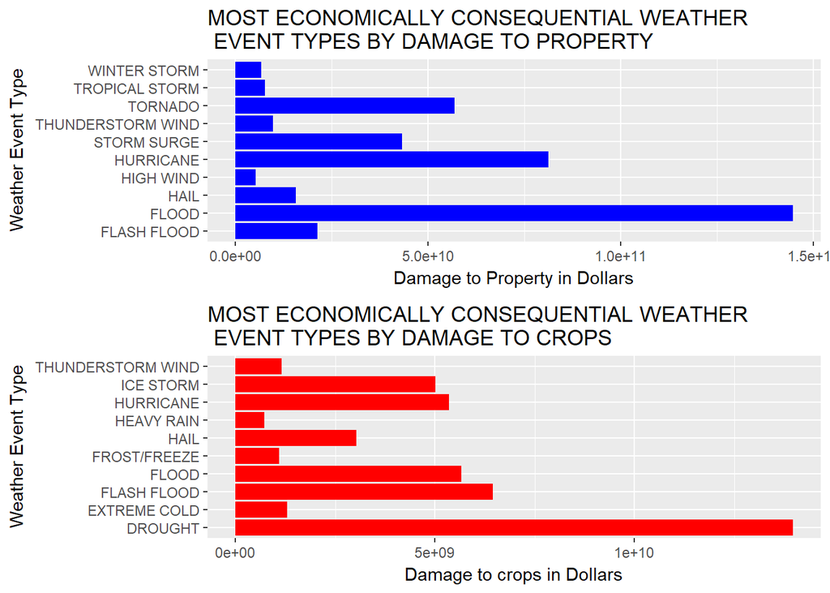

```r
library(grid)
plotC <- ggplot(data = head(c,10)) + geom_col(aes(x= EVTYPE, y = PROPDMG), fill = "blue") + ggtitle("MOST ECONOMICALLY CONSEQUENTIAL WEATHER \n EVENT TYPES BY DAMAGE TO PROPERTY") + xlab("Weather Event Type") + ylab("Damage to Property in Dollars") + coord_flip()

plotD <- ggplot(data = head(d,10)) + geom_col(aes(x = EVTYPE, y = CROPDMG), fill = "red") + ggtitle("MOST ECONOMICALLY CONSEQUENTIAL WEATHER \n EVENT TYPES BY DAMAGE TO CROPS") + xlab("Weather Event Type") + ylab("Damage to crops in Dollars") + coord_flip()

grid.arrange(plotC, plotD, nrow = 2)
```

## Conclusion

This analysis sought to determine which weather event types were the most harmful to population health and which weather event types had the greatest economic consequences. The analysis reveals that tornadoes are the most harmful weather event types in the USA, both in terms of fatalities and injuries. The analysis also reveals that floods have the greatest economic consequences in terms of damage to property and droughts have the greatest economic consequences in terms of damage to crops.